# Visualizacion

## Análisis de datos de tráfico - aire (C.Madrid)

El portal de datos abiertos del Ayuntamiento de Madrid (http://datos.madrid.es/portal/site/egob) pone a disposición gran cantidad de datasets.

- **Datos de observaciones de puntos de medida de tráfico**

La descripción de los datos y los ficheros en formato CSV comprimido se pueden encuentran en los siguientes enlaces:

- Datos históricos de Tráfico

Distintos sensores de control de tráfico de la Comunidad de Madrid proporcionan datos sobre la intensidad de tráfico cada 15 minutos.

```python
# importar librerías necesarias para la ejecución

import pandas as pd
import numpy as np

# visualización
import seaborn as sns
import matplotlib.pyplot as plt
%matplotlib inline

## sistema operativo
import os
from os import listdir
from os.path import isfile, join

import zipfile
import time
```

## Leer los datos

```python
# acceso en modo lectura al fichero comprimido
zf = zipfile.ZipFile( "./pd_trafico/trafico_m30.zip", 'r')

# crear un dataframe llamado tf
tf = pd.read_csv(zf.open(zf.namelist()[0]), parse_dates =[1])
```

```python
tf         # acceso al contenido
```

|  | idelem | fecha | dia | tipo_elem | intensidad | ocupacion | periodo_integracion |
| --- | --- | --- | --- | --- | --- | --- | --- |
| 0 | 1010 | 2017-02-13 11:45:00 | 13 | M-30 | 2640 | 5 | 5 |
| 1 | 1044 | 2017-02-13 11:45:00 | 13 | M-30 | 948 | 6 | 5 |
| 2 | 3542 | 2017-02-13 11:45:00 | 13 | M-30 | 2592 | 7 | 5 |
| 3 | 7119 | 2017-02-13 11:45:00 | 13 | M-30 | 1728 | 7 | 5 |
| 4 | 1021 | 2017-02-13 11:45:00 | 13 | M-30 | 2364 | 6 | 5 |
| 5 | 7121 | 2017-02-13 11:45:00 | 13 | M-30 | 2868 | 7 | 5 |
| 6 | 6849 | 2017-02-13 11:45:00 | 13 | M-30 | 996 | 6 | 5 |
| 7 | 6858 | 2017-02-13 11:45:00 | 13 | M-30 | 3072 | 11 | 5 |
| 8 | 6850 | 2017-02-13 11:45:00 | 13 | M-30 | 2964 | 10 | 5 |
| 9 | 6856 | 2017-02-13 11:45:00 | 13 | M-30 | 336 | 3 | 5 |
| 10 | 1032 | 2017-02-13 11:45:00 | 13 | M-30 | 324 | 3 | 5 |
| 11 | 6857 | 2017-02-13 11:45:00 | 13 | M-30 | 864 | 7 | 5 |
| 12 | 1033 | 2017-02-13 11:45:00 | 13 | M-30 | 480 | 6 | 5 |
| 13 | 6848 | 2017-02-13 11:45:00 | 13 | M-30 | 396 | 4 | 5 |
| 14 | 6855 | 2017-02-13 11:45:00 | 13 | M-30 | 264 | 3 | 5 |
| 15 | 1034 | 2017-02-13 11:45:00 | 13 | M-30 | 552 | 7 | 5 |
| 16 | 1037 | 2017-02-13 11:45:00 | 13 | M-30 | 468 | 8 | 5 |
| 17 | 6864 | 2017-02-13 11:45:00 | 13 | M-30 | 660 | 8 | 5 |
| 18 | 1031 | 2017-02-13 11:45:00 | 13 | M-30 | 1236 | 43 | 5 |
| 19 | 1036 | 2017-02-13 11:45:00 | 13 | M-30 | 108 | 0 | 5 |
| 20 | 1035 | 2017-02-13 11:45:00 | 13 | M-30 | 156 | 2 | 5 |
| 21 | 6862 | 2017-02-13 11:45:00 | 13 | M-30 | 60 | 7 | 5 |
| 22 | 6851 | 2017-02-13 11:45:00 | 13 | M-30 | 228 | 1 | 5 |
| 23 | 6853 | 2017-02-13 11:45:00 | 13 | M-30 | 840 | 37 | 5 |
| 24 | 6854 | 2017-02-13 11:45:00 | 13 | M-30 | 2508 | 9 | 5 |
| 25 | 6847 | 2017-02-13 11:45:00 | 13 | M-30 | 4308 | 9 | 5 |
| 26 | 6845 | 2017-02-13 11:45:00 | 13 | M-30 | 4104 | 8 | 5 |
| 27 | 1040 | 2017-02-13 11:45:00 | 13 | M-30 | 180 | 3 | 5 |
| 28 | 1039 | 2017-02-13 11:45:00 | 13 | M-30 | 36 | 14 | 5 |
| 29 | 6846 | 2017-02-13 11:45:00 | 13 | M-30 | 4956 | 21 | 5 |
| ... | ... | ... | ... | ... | ... | ... | ... |
| 1007193 | 1042 | 2017-02-28 09:45:00 | 28 | M-30 | 744 | 7 | 5 |
| 1007194 | 1011 | 2017-02-28 09:45:00 | 28 | M-30 | 1848 | 8 | 5 |
| 1007195 | 6837 | 2017-02-28 09:45:00 | 28 | M-30 | 1536 | 7 | 5 |
| 1007196 | 1043 | 2017-02-28 09:45:00 | 28 | M-30 | 924 | 2 | 5 |
| 1007197 | 1045 | 2017-02-28 09:45:00 | 28 | M-30 | 0 | 0 | 5 |
| 1007198 | 3546 | 2017-02-28 09:45:00 | 28 | M-30 | 96 | 1 | 5 |
| 1007199 | 6838 | 2017-02-28 09:45:00 | 28 | M-30 | 2316 | 6 | 5 |
| 1007200 | 1013 | 2017-02-28 09:45:00 | 28 | M-30 | 2244 | 6 | 5 |
| 1007201 | 1018 | 2017-02-28 09:45:00 | 28 | M-30 | 4080 | 9 | 5 |
| 1007202 | 7123 | 2017-02-28 09:45:00 | 28 | M-30 | 4056 | 12 | 5 |
| 1007203 | 7122 | 2017-02-28 09:45:00 | 28 | M-30 | 3720 | 17 | 5 |
| 1007204 | 6880 | 2017-02-28 09:45:00 | 28 | M-30 | 240 | 2 | 5 |
| 1007205 | 6881 | 2017-02-28 09:45:00 | 28 | M-30 | 504 | 4 | 5 |
| 1007206 | 6882 | 2017-02-28 09:45:00 | 28 | M-30 | 540 | 3 | 5 |
| 1007207 | 6890 | 2017-02-28 09:45:00 | 28 | M-30 | 432 | 3 | 5 |
| 1007208 | 6888 | 2017-02-28 09:45:00 | 28 | M-30 | 528 | 4 | 5 |
| 1007209 | 6889 | 2017-02-28 09:45:00 | 28 | M-30 | 732 | 7 | 5 |
| 1007210 | 6883 | 2017-02-28 09:45:00 | 28 | M-30 | 768 | 4 | 5 |
| 1007211 | 6884 | 2017-02-28 09:45:00 | 28 | M-30 | 264 | 2 | 5 |
| 1007212 | 1047 | 2017-02-28 09:45:00 | 28 | M-30 | 1248 | 6 | 10 |
| 1007213 | 6846 | 2017-02-28 09:45:00 | 28 | M-30 | 4956 | 14 | 5 |
| 1007214 | 6844 | 2017-02-28 09:45:00 | 28 | M-30 | 4092 | 11 | 5 |
| 1007215 | 3818 | 2017-02-28 09:45:00 | 28 | M-30 | 3472 | 9 | 15 |
| 1007216 | 3819 | 2017-02-28 09:45:00 | 28 | M-30 | 6829 | 11 | 15 |
| 1007217 | 3820 | 2017-02-28 09:45:00 | 28 | M-30 | 5128 | 15 | 15 |
| 1007218 | 6663 | 2017-02-28 09:45:00 | 28 | M-30 | 4300 | 14 | 15 |
| 1007219 | 3799 | 2017-02-28 09:45:00 | 28 | M-30 | 4940 | 10 | 15 |
| 1007220 | 3800 | 2017-02-28 09:45:00 | 28 | M-30 | 2312 | 9 | 15 |
| 1007221 | 6664 | 2017-02-28 09:45:00 | 28 | M-30 | 4008 | 11 | 15 |
| 1007222 | 6665 | 2017-02-28 09:45:00 | 28 | M-30 | 3724 | 9 | 15 |

1007223 rows × 7 columns

#### Descripción de los datos de tráfico

En el propio portal podemos encontrar información acerca del contenido de los ficheros ([info tráfico](http://datos.madrid.es/FWProjects/egob/contenidos/datasets/ficheros/Estructura%20y%20contenido%20del%20fichero%20csv.pdf)).

- `idelem`: Identificación única del Punto de Medida en los sistemas de control del tráfico del Ayuntamiento de Madrid.
- `fecha`: fecha en formato Año, mes, día, hora, minutos, segundos
- `intensidad`: Intensidad del Punto de Medida en el periodo de 15 minutos (vehículos/hora).
- `periodo_integracion`: Número de muestras recibidas y consideradas

### Análisis estadístico

Con los dataframes creados es posible realizar operaciones estadísticas mediante las funciones y métodos proporcionados por la librería. Por ejemplo, la media, la suma, etc...

```python
# valor máximo de intensidad en el mes de febrero de 2017
tf.intensidad.max()
```

```
9232
```

```python
# valor mínimo de intensidad en el mes de febrero de 2017
tf.intensidad.min()
```

```
0
```

```python
# valor medio
tf.intensidad.mean()
```

```
1448.6415868184106
```

```python
# desviación típica
tf.intensidad.std()
```

```
1503.6626200542519
```

```python
# suma de todas la intensidades
tf.intensidad.sum()
```

```
1459105125
```

El método `describe()` calcula los primeros estadísticos para las columnas numéricas:

```python
tf.describe()
```

|  | idelem | dia | intensidad | ocupacion | periodo_integracion |
| --- | --- | --- | --- | --- | --- |
| count | 1.007223e+06 | 1.007223e+06 | 1.007223e+06 | 1.007223e+06 | 1.007223e+06 |
| mean | 5.633721e+03 | 1.450454e+01 | 1.448642e+03 | 6.390920e+00 | 1.160698e+01 |
| std | 2.082249e+03 | 8.088312e+00 | 1.503663e+03 | 7.706981e+00 | 4.725230e+00 |
| min | 1.001000e+03 | 1.000000e+00 | 0.000000e+00 | -1.000000e+00 | 1.000000e+00 |
| 25% | 3.822000e+03 | 7.000000e+00 | 2.640000e+02 | 1.000000e+00 | 5.000000e+00 |
| 50% | 6.731000e+03 | 1.400000e+01 | 8.880000e+02 | 5.000000e+00 | 1.500000e+01 |
| 75% | 6.842000e+03 | 2.200000e+01 | 2.235000e+03 | 9.000000e+00 | 1.500000e+01 |
| max | 1.018000e+04 | 2.800000e+01 | 9.232000e+03 | 9.800000e+01 | 1.600000e+01 |

## Visualización

Existen varias librerías para realizar las tareas de visualización:

### Matplotlib

Matplotlib es una de las librerías en Python más utilizadas en ciencia de datos.

- Una de las características que hace que tenga éxito es **la facilidad de uso**
- Visualizaciones de datos con **muy pocas líneas de código**
- Los gráficos se puedan incluir en cualquier proyecto web
- Diagramas de barras

Gráficos de áreas, histogramas, visualizaciones de líneas, barras, diagramas de dispersión… matplotlib es una de las librerías en Python más utilizadas en ciencia de datos.

[Librería gráfica matplotlib](http://matplotlib.org/) (http://matplotlib.org/)

```python
import matplotlib.pyplot as plt
%matplotlib inline
```

#### Diagrama de barras

Representación de la intensidad media por día del mes.

```python
# intensidad media de tráfico recogida por cada estación cada día de la semana
# preparo los datos: agrupo por día y calculo la media de la intensidad
pordias = tf.groupby(['dia']).intensidad.mean().reset_index()
```

```python
pordias.head()
```

|  | dia | intensidad |
| --- | --- | --- |
| 0 | 1 | 1562.337471 |
| 1 | 2 | 1572.550222 |
| 2 | 3 | 1599.078592 |
| 3 | 4 | 1175.492921 |
| 4 | 5 | 1036.042030 |

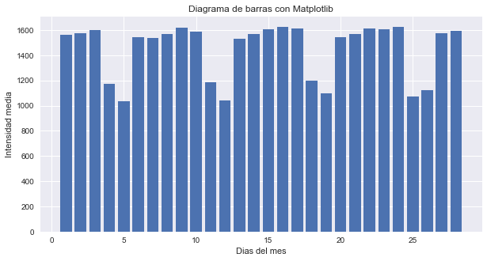

```python
fig, ax = plt.subplots(nrows = 1, figsize=(10,5))
ax.bar(pordias.dia, pordias.intensidad)
ax.legend(loc=0)

ax.set_title('Diagrama de barras con Matplotlib')
ax.set_xlabel('Dias del mes')
ax.set_ylabel('Intensidad media');
```

### Seaborn

Seaborn es una librería de visualización de datos en Python basada en matplotlib. Sus características:

- Mejora el diseño de matplotlib.
- Dispone de herramientas para la elección de paletas de colores.
- Funciones para comparar subconjuntos de datos.
- Herramientas para adaptar y visualizar modelos de regresión lineal.
- Funciones para visualizar matrices de datos.
- Uso de algoritmos de clustering.
- Posibilidad de establecer series temporales estadísticas con los datos.

[Seaborn](https://seaborn.pydata.org/) (https://seaborn.pydata.org/)

```python
# módulos necesarios
import seaborn as sns
import numpy as np
import matplotlib.pyplot as plt
%matplotlib inline
```

#### Diagrama de barras con Seaborn

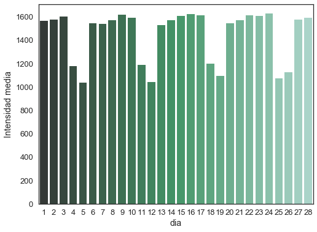

```python
sns.set(style="white", context="talk")

# figuras
f, ax1 = plt.subplots(1, figsize=(8, 6))

# Ejemplo 1
sns.barplot(pordias.dia, pordias.intensidad, palette="BuGn_d", ax=ax1)
ax1.set_ylabel("Intensidad media");
```

#### Diagramas de calor

Creamos un dataframe aplicando el método `pivot_table`. La nueva tabla se crea a partir de 3 columnas.

```python
tf_p = tf.pivot_table(index = "idelem", columns = "dia", values = "intensidad")
```

```python
tf_p.head(10)
```

| dia idelem | 1 | 2 | 3 | 4 | 5 | 6 | 7 | 8 | 9 | 10 | ... | 19 | 20 | 21 | 22 | 23 | 24 | 25 | 26 | 27 | 28 |
| --- | --- | --- | --- | --- | --- | --- | --- | --- | --- | --- | --- | --- | --- | --- | --- | --- | --- | --- | --- | --- | --- |
| 1001 | 1854.416667 | 1903.354167 | 2023.28125 | 1656.604167 | 1049.250000 | 1887.500 | 1705.750000 | 1954.375000 | 2241.500000 | 2064.3750 | ... | 1438.916667 | 1939.708333 | 2049.020833 | 2197.12500 | 2038.75000 | 2165.406250 | 584.65625 | 1481.375000 | 1773.854167 | 1886.250 |
| 1002 | 2249.500000 | 2258.250000 | 2328.12500 | 1716.229167 | 1492.500000 | 2238.000 | 2180.312500 | 2169.375000 | 2313.000000 | 2353.5000 | ... | 1551.666667 | 2150.833333 | 2229.354167 | 2287.18750 | 2312.84375 | 2405.364583 | 527.65625 | 1600.041667 | 2271.562500 | 2302.000 |
| 1003 | 2968.041667 | 3023.416667 | 3073.25000 | 2276.666667 | 1969.125000 | 2935.375 | 2881.062500 | 2849.875000 | 3024.125000 | 3075.3750 | ... | 2050.666667 | 2872.208333 | 2953.104167 | 3018.62500 | 3093.25000 | 3183.229167 | 821.96875 | 2260.645833 | 2981.208333 | 3013.375 |
| 1006 | 2313.437500 | 2329.791667 | 2327.15625 | 1753.468750 | 1530.750000 | 2256.375 | 2192.812500 | 2271.000000 | 2359.250000 | 2497.6250 | ... | 1574.875000 | 2206.875000 | 2247.645833 | 2287.65625 | 2376.53125 | 2484.968750 | 677.84375 | 1700.062500 | 2315.895833 | 2339.125 |
| 1009 | 2329.875000 | 2361.708333 | 2377.68750 | 1753.625000 | 1564.500000 | 2265.875 | 2303.625000 | 2269.500000 | 2389.250000 | 2388.6250 | ... | 1566.208333 | 2258.666667 | 2309.770833 | 2376.03125 | 2382.90625 | 2442.187500 | 852.96875 | 1721.104167 | 2345.427083 | 2386.875 |
| 1010 | 2265.062500 | 2319.687500 | 2308.71875 | 1694.500000 | 1419.083333 | 2466.750 | 2030.458333 | 2568.166667 | 2929.833333 | 2927.4375 | ... | 1998.166667 | 2000.239583 | 1748.666667 | 1164.37500 | 1696.50000 | 1820.291667 | 479.50000 | 743.166667 | 1685.270833 | 1747.000 |
| 1011 | 1414.312500 | 1424.062500 | 1451.84375 | 1006.260417 | 931.625000 | 1400.750 | 1374.187500 | 1395.875000 | 1468.625000 | 1433.1250 | ... | 965.875000 | 1420.000000 | 1425.729167 | 1423.87500 | 1411.40625 | 1498.270833 | 447.71875 | 1052.208333 | 1420.302083 | 1485.375 |
| 1012 | 647.354167 | 664.562500 | 717.84375 | 509.864583 | 496.125000 | 670.375 | 661.125000 | 689.125000 | 708.125000 | 767.3750 | ... | 500.541667 | 679.541667 | 667.270833 | 673.96875 | 700.12500 | 763.114583 | 274.28125 | 556.250000 | 696.000000 | 687.875 |
| 1013 | 1983.791667 | 1979.041667 | 1996.90625 | 1359.802083 | 1266.250000 | 1912.500 | 1994.437500 | 1985.625000 | 2027.875000 | 1962.6250 | ... | 1401.375000 | 1984.375000 | 2038.916667 | 2052.81250 | 2051.62500 | 2049.479167 | 809.34375 | 1442.270833 | 1997.864583 | 2006.500 |
| 1014 | 1165.604167 | 1143.791667 | 1154.96875 | 837.614583 | 731.250000 | 1111.500 | 1107.187500 | 1130.500000 | 1169.500000 | 1149.5000 | ... | 785.833333 | 1133.250000 | 1152.958333 | 1145.87500 | 1166.12500 | 1213.302083 | 316.59375 | 896.666667 | 1162.145833 | 1175.375 |

10 rows × 28 columns

Construimos un diagrama de calor de las 10 primeras estaciones:

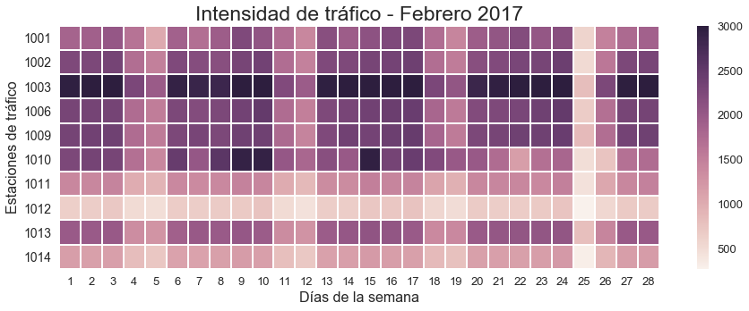

```python
fig, g = plt.subplots(figsize=(15, 5))
# mapa de calor
sns.heatmap(tf_p.head(10), annot=False, vmax=3000, linewidths=1, ax = g);

# decoración
g.set_title('Intensidad de tráfico - Febrero 2017', fontsize = 23);
g.axes.xaxis.set_label_text("Días de la semana", fontdict={"size":16})
g.axes.yaxis.set_label_text("Estaciones de tráfico", fontdict={"size":16})
plt.yticks( rotation='horizontal', fontsize = 14);
```

### Bokeh

Se trata de una librería al estilo JavaScript D3.js.

- Es una librería **interactiva**.
- Cada gráfico tiene asociado su código HTML para incluirlo en una página web.
- Consultar la galería http://bokeh.pydata.org/en/latest/docs/gallery.html

#### Series de tiempo

Representación de la evolución de la media de la intensidad a lo largo del tiempo:

```python
porfecha = tf.groupby(['fecha']).intensidad.mean().reset_index()
porfecha.head()
```

|  | fecha | intensidad |
| --- | --- | --- |
| 0 | 2017-02-01 00:00:00 | 496.671088 |
| 1 | 2017-02-01 00:15:00 | 451.864721 |
| 2 | 2017-02-01 00:30:00 | 397.740053 |
| 3 | 2017-02-01 00:45:00 | 329.132626 |
| 4 | 2017-02-01 01:00:00 | 267.466844 |

```python
from bokeh.plotting import figure, output_notebook, show, output_file
output_notebook()    # para visualizar el gráfico en el notebook


output_file("datetime.html")
p = figure(title="Series de tiempo", plot_width=600, plot_height=300, x_axis_type="datetime")
p.line(porfecha.fecha, porfecha.intensidad, color='navy', alpha=0.8)

show(p)
```

[interactive chart not shown]

## Otra librería de Visualización: python-higthcharts

HighChart es una librería escrita en Javascript que permite la creación de gráficas. La librería ofrece un método fácil e interactivo para insertar graficas en su sitio web o aplicación web.

```python
from highcharts import Highchart # import highchart library
H = Highchart(width=650, height=400)
data = [{
            'name': "Microsoft Internet Explorer",
            'y': 56.33,
            'drilldown': "Microsoft Internet Explorer"
        }, {
            'name': "Chrome",
            'y': 24.030000000000005,
            'drilldown': "Chrome"
        }, {
            'name': "Firefox",
            'y': 10.38,
            'drilldown': "Firefox"
        }, {
            'name': "Safari",
            'y': 4.77,
            'drilldown': "Safari"
        }, {
            'name': "Opera",
            'y': 0.9100000000000001,
            'drilldown': "Opera"
        }, {
            'name': "Proprietary or Undetectable",
            'y': 0.2,
            'drilldown': None
        }]

data_1 = [
    ["v11.0", 24.13],
    ["v8.0", 17.2],
    ["v9.0", 8.11],
    ["v10.0", 5.33],
    ["v6.0", 1.06],
    ["v7.0", 0.5]
]

data_2 = [
    ["v40.0", 5],
    ["v41.0", 4.32],
    ["v42.0", 3.68],
    ["v39.0", 2.96],
    ["v36.0", 2.53],
    ["v43.0", 1.45],
    ["v31.0", 1.24],
    ["v35.0", 0.85],
    ["v38.0", 0.6],
    ["v32.0", 0.55],
    ["v37.0", 0.38],
    ["v33.0", 0.19],
    ["v34.0", 0.14],
    ["v30.0", 0.14]
]

data_3 = [
    ["v35", 2.76],
    ["v36", 2.32],
    ["v37", 2.31],
    ["v34", 1.27],
    ["v38", 1.02],
    ["v31", 0.33],
    ["v33", 0.22],
    ["v32", 0.15]
]
data_4 = [
    ["v8.0", 2.56],
    ["v7.1", 0.77],
    ["v5.1", 0.42],
    ["v5.0", 0.3],
    ["v6.1", 0.29],
    ["v7.0", 0.26],
    ["v6.2", 0.17]
]

data_5 = [
    ["v12.x", 0.34],
    ["v28", 0.24],
    ["v27", 0.17],
    ["v29", 0.16]
]

# Añadimos los datos
H.add_data_set(data, series_type = 'column', name = "Marcas", colorByPoint= True)

H.add_drilldown_data_set(data_1, 'column', 'Microsoft Internet Explorer', name='Microsoft Internet Explorer' )
H.add_drilldown_data_set(data_2, 'column', 'Chrome', name='Chrome')
H.add_drilldown_data_set(data_3, 'column', 'Firefox', name='Firefox')
H.add_drilldown_data_set(data_4, 'column', 'Safari', name='Safari')
H.add_drilldown_data_set(data_5, 'column', 'Opera', name='Opera')

# Especificamos las opciones del grágico


options = {
    'chart': {
        'type': 'column'
    },
    'title': {
        'text': 'Browser market shares. January, 2015 to May, 2015'
    },
    'subtitle': {
        'text': 'Click the columns to view versions. Source: <a href="http://netmarketshare.com">netmarketshare.com</a>.'
    },
    'xAxis': {
        'type': 'category'
    },
    'yAxis': {
        'title': {
            'text': 'Total percent market share'
        }

    },
    'legend': {
        'enabled': False
    },
    'plotOptions': {
        'series': {
            'borderWidth': 0,
            'dataLabels': {
                'enabled': True,
                'format': '{point.y:.1f}%'
            }
        }
    },

    'tooltip': {
        'headerFormat': '<span style="font-size:11px">{series.name}</span><br>',
        'pointFormat': '<span style="color:{point.color}">{point.name}</span>: <b>{point.y:.2f}%</b> of total<br/>'
    },

}
H.set_dict_options(options)
H
```

[interactive chart not shown]

## References

- [Tutorial de Python. Por Guido Van Rossum](http://docs.python.org.ar/tutorial/pdfs/TutorialPython3.pdf)
- [Python for Data Analysis](http://shop.oreilly.com/product/0636920023784.do) (http://shop.oreilly.com/product/0636920023784.do)
- [Librería gráfica matplotlib](http://matplotlib.org/) (http://matplotlib.org/)
- [Seaborn](https://seaborn.pydata.org/) (https://seaborn.pydata.org/)
- [Bokeh](http://bokeh.pydata.org/en/latest/) (http://bokeh.pydata.org/en/latest/)